# Assignment 4: Sensitivity with LHS

Nick McManus, Caroline Shepherd, Alia Ajina

2023-05-02

## Latin Hypercube

First, we’ll generate a list of samples of our four parameters (wind speed, vegetation height, roughness, and zero plane displacement) using the Latin Hypercube method. These values are stored in the object `parm`.

```r
## Setting a random seed to make things 'random'
set.seed(1)

pnames = c("v", "height", "k_o", "k_d")

## Set the number of parameters (same as pnames)
npar = length(pnames)

## Choose how many samples to generate
nsample = 100

## Create matrix with LHS values based on sample size and parameter names
parm_quant = randomLHS(nsample, npar)
colnames(parm_quant)=pnames


## Create empty df to store values in next step
## Make sure it is the same size as our parm_quant matrix
parm = as.data.frame(matrix(nrow=nrow(parm_quant), ncol=ncol(parm_quant)))
colnames(parm) = pnames

## Now we fill in the columns in the df with normal/uniform distributed values that are pulled from parm_quant matrix
parm[,"v"] = qnorm(parm_quant[,"v"], mean = 250, sd=30)
parm[,"height"] = qunif(parm_quant[,"height"], min = 9.5, max = 10.5)

## SD for k_o and k_d values vary by 1%
pvar = 0.01
parm[, "k_o"] = qnorm(parm_quant[, "k_o"], mean = 0.1, sd = 0.1*pvar)
parm[, "k_d"] = qnorm(parm_quant[, "k_d"], mean = 0.7, sd = 0.7*pvar)
```

## Run the model

Now we’ll run our atmospheric conductance model using our LHS values. The conductance model results are then bound together with the input parameter values to easily plot and view sensitivities by parameter.

```r
## Read in function
source(here("R/Catm.R"))

## Run fxn over all parm values using pmap
results <- pmap(.l = parm, .f = Catm)

## Convert results into tidy df
results_df <- as.data.frame(results) %>%
  pivot_longer(everything()) %>%
  select(value) %>%
  rename(cond_value = value)

## Bind conductance results to input parms
cond <- cbind.data.frame(parm, results_df)

## Use `gather()` to pivot the parms table into tidy format for plots
cond_tidy =  cond %>%  gather(v, height, k_o, k_d, value="parmvalue", key="parm")

## Considered making violin plots but we decided to create density plots instead
cond_violin <- cond_tidy %>%
  filter(parm == "v")
```

## Plot results

First, we’ll visualize the parameter uncertainty used in generating our conductance estimates through a series of density plots. As displayed below, the vegetation height parameter samples were uniformly distributed, while the remaining three parameters samples were normally distributed.

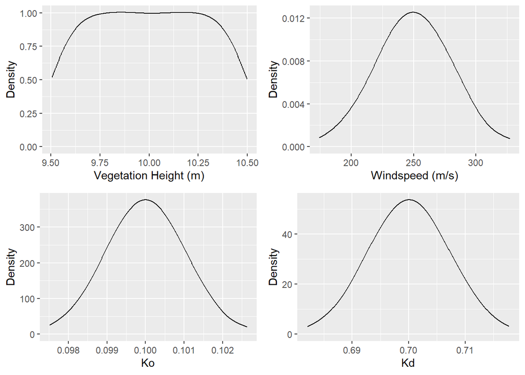

```r
# Density plots to display parameter uncertainty input values
p1<-ggplot(data = cond, aes(x = height)) +
  geom_density() + labs(x = "Vegetation Height (m)", y = "Density")

p2<-ggplot(data=cond, aes(x=v)) +
  geom_density() + labs(x = "Windspeed (m/s)", y = "Density")

p3<-ggplot(data=cond, aes(x=k_o)) +
  geom_density() + labs(x = "Ko", y = "Density")

p4<-ggplot(data=cond, aes(x=k_d)) +
  geom_density() + labs(x = "Kd", y = "Density")


## Arranging our density plots
ggarrange(p1, p2, p3, p4)
```

Next, we’ll plot the model conductance estimates against each of the parameters. These results demonstrate that wind speed has the strongest linear relationship with the conductance model outputs.

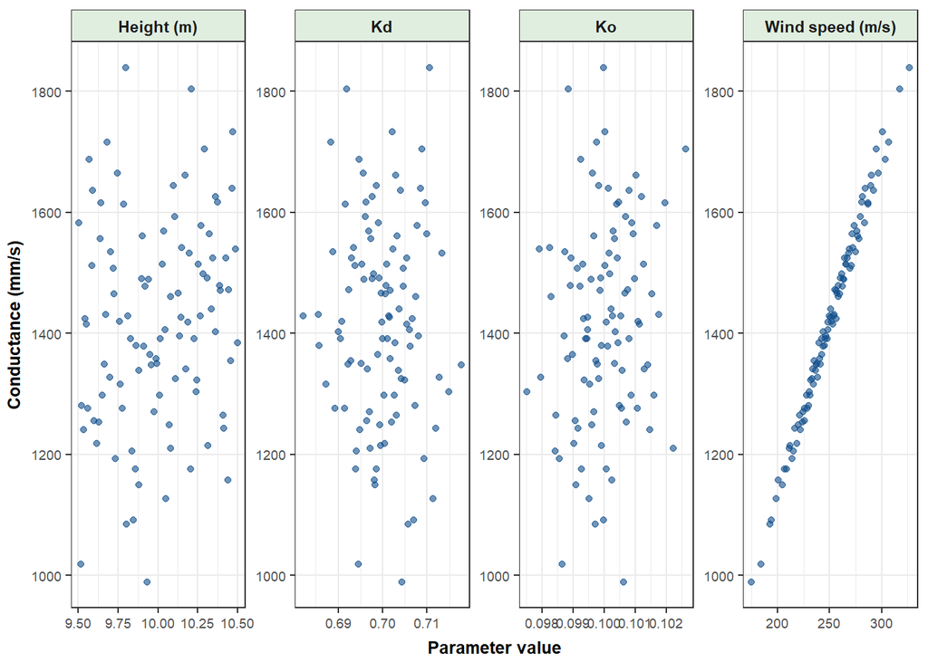

```r
## Labels for facet wrap
parm_labs <- c("Height (m)", "Kd", "Ko", "Wind speed (m/s)")
names(parm_labs) <- c("height", "k_d", "k_o", "v")

## Plotting our parameter sensitivity
ggplot(data = cond_tidy, aes(x = parmvalue, y = cond_value))+
  geom_point(col = 'dodgerblue4', alpha = 0.6, size = 1.5) +
  facet_wrap(~parm, scales="free", ncol=4,
             labeller = labeller(parm = parm_labs)) +
  labs(y = "Conductance (mm/s)",
       x = "Parameter value") +
theme_bw() +
  theme(
    axis.title.x = element_text(face = 'bold', size = 9.5, vjust = -0.5),
    axis.title.y = element_text(face = 'bold', size = 9.5, vjust = 2),
    axis.text = element_text(size = 7),
    panel.grid.minor.y = element_blank(),
    strip.text = element_text(face = 'bold'),
    strip.background = element_rect(fill = 'honeydew2'),
    legend.position = "none"
  )
```

Finally, we’ll find the partial rank correlation coefficient values and plot the results below.

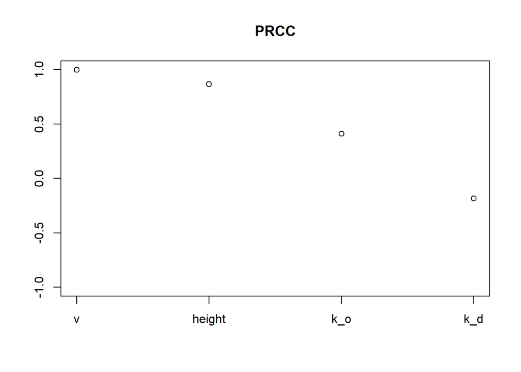

```r
sen_result = pcc(X = parm, y = results_df$cond_value, rank = TRUE)

## Plot of results
plot(sen_result)
```

Our results tell us that aerodynamic conductance is most sensitive to wind speed, followed by vegetation height. This suggests that it’s vital to have accurate windspeed data to reduce uncertainties. As the climate changes, increased conductance could increase the amount of water that plants require. This is particularly true if climate change results in increased windspeeds, which in turn will cause higher evapotranspiration rates. More accurate projections of future windspeed and plant height would therefore lead to decreased uncertainty in aerodynamic conductance estimates and plant water use.